# RA

# 12.3 Annotations

## 12.3.1 Exercises

1.Use geom_text() with infinite positions to place text at the four corners of the plot.

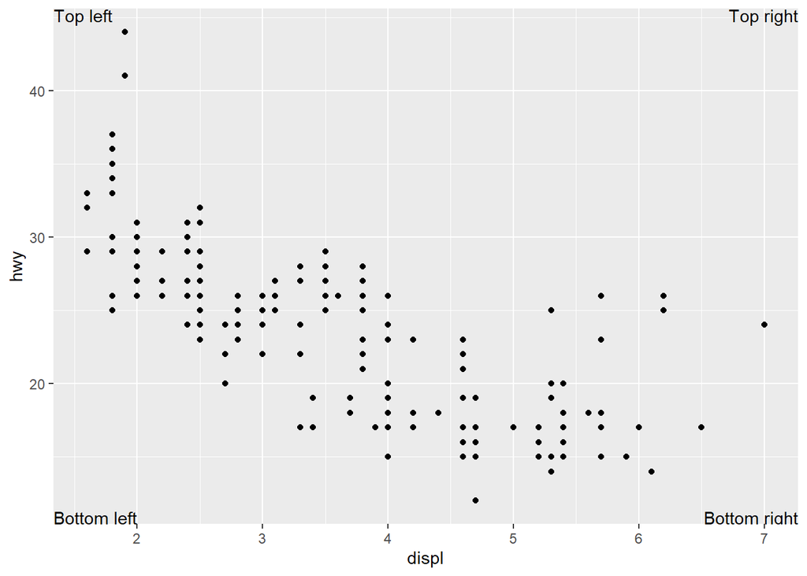

```r
label <- tribble(
  ~displ, ~hwy, ~label, ~vjust, ~hjust,
  Inf, Inf, "Top right", "top", "right",
  Inf, -Inf, "Bottom right", "bottom", "right",
  -Inf, Inf, "Top left", "top", "left",
  -Inf, -Inf, "Bottom left", "bottom", "left"
)

ggplot(mpg, aes(displ, hwy)) +
  geom_point() +
  geom_text(aes(label = label, vjust = vjust, hjust = hjust), data = label)
```

2. Use annotate() to add a point geom in the middle of your last plot without having to create a tibble. Customize the shape, size, or color of the point.

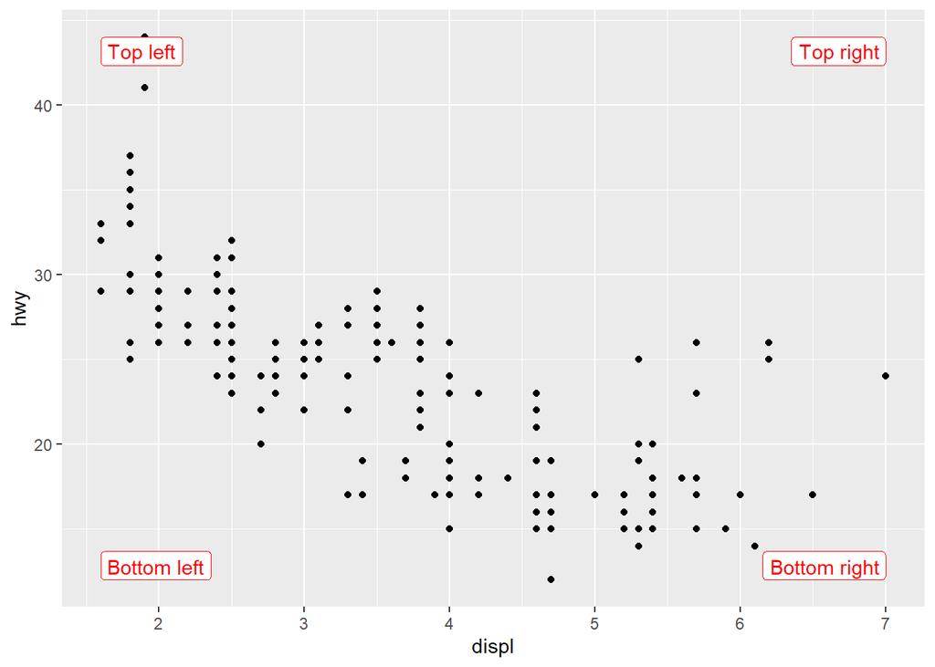

```r
ggplot(mpg, aes(x = displ, y = hwy)) +
  geom_point() +
   annotate(geom = "label", x= max(mpg$displ), y= max(mpg$hwy),
    label = "Top right", vjust = "top",
    hjust = "right", color = "red"
  ) +
   annotate(geom = "label", x= min(mpg$displ), y= max(mpg$hwy),
    label = "Top left", vjust = "top",
    hjust = "left", color = "red"
  ) +
   annotate(geom = "label", x= max(mpg$displ), y= min(mpg$hwy),
    label = "Bottom right", vjust = "bottom",
    hjust = "right", color = "red"
  ) +
   annotate(geom = "label", x= min(mpg$displ), y= min(mpg$hwy),
    label = "Bottom left", vjust = "bottom",
    hjust = "left", color = "red"
  )
```

3. How do labels with geom_text() interact with faceting? How can you add a label to a single facet? How can you put a different label in each facet? (Hint: Think about the dataset that is being passed to geom_text().)

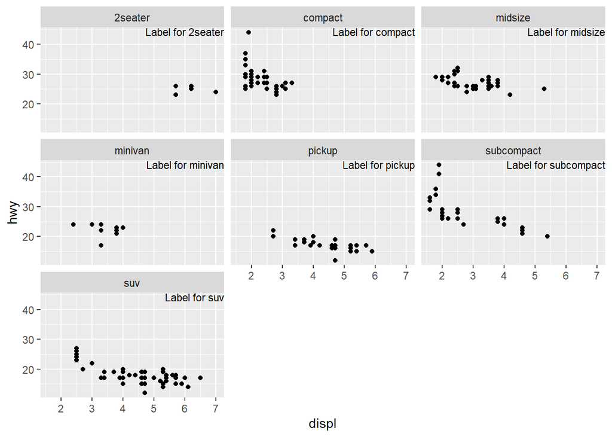

```r
# labels in each different plots
label <- tibble(
  displ = Inf,
  hwy = Inf,
  class = unique(mpg$class),
  label = str_c("Label for ", class)
)

ggplot(mpg, aes(displ, hwy)) +
  geom_point() +
  geom_text(aes(label = label),
    data = label, vjust = "top", hjust = "right",
    size = 3
  ) +
  facet_wrap(~class)
```

4. What arguments to geom_label() control the appearance of the background box?

-label.padding: padding around label -label.r: amount of rounding in the corners -label.size: size of label border

5. What are the four arguments to arrow()? How do they work? Create a series of plots that demonstrate the most important options.

-angle : angle of arrow head -length : length of the arrow head -ends: ends of the line to draw arrow head -type: “open” or “close”: whether the arrow head is a closed or open triangle

## 12.4 Scales

### 12.4.1 Default scales

- scale_ followed by the name of the aesthetic, then _, then the name of the scale. The default scales are named according to the type of variable they align with: continuous, discrete, datetime, or date. scale_x_continuous() puts the numeric values from displ on a continuous number line on the x-axis, scale_color_discrete() chooses colors for each of the class of car, etc.

### 12.4.2 Axis ticks and legend keys

-There are two primary arguments that affect the appearance of the ticks on the axes and the keys on the legend: breaks and labels. Breaks controls the position of the ticks, or the values associated with the keys. Labels controls the text label associated with each tick/key.

-We can use the labels in the same way. label_dollar will add dollar sign. label_percent() add percentage.

### 12.4.3 Legend layout

-To control the overall position of the legend, you need to use a theme() setting.The theme setting legend.position controls where the legend is drawn.

-To control the display of individual legends, use guides() along with guide_legend() or guide_colorbar(). Note that the name of the argument in guides() matches the name of the aesthetic, just like in labs().

### 12.4.4 Replacing a scale

-It’s very useful to plot transformations of your variable. The ColorBrewer scales are documented online at https://colorbrewer2.org/ and made available in R via the RColorBrewer package, by Erich Neuwirth.

-For continuous color, you can use the built-in scale_color_gradient() or scale_fill_gradient(). If you have a diverging scale, you can use scale_color_gradient2().

-Note that all color scales come in two varieties: scale_color_*() and scale_fill_*() for the color and fill aesthetics respectively (the color scales are available in both UK and US spellings).

### 12.4.5 Zooming

-There are three ways to control the plot limits:

-Adjusting what data are plotted. -Setting the limits in each scale. -Setting xlim and ylim in coord_cartesian().

-To zoom in on a region of the plot, it’s generally best to use coord_cartesian().

-Setting the limits on individual scales is generally more useful if you want to expand the limits, e.g., to match scales across different plots.

### 12.4.6 Exercises

1. Why doesn’t the following code override the default scale?

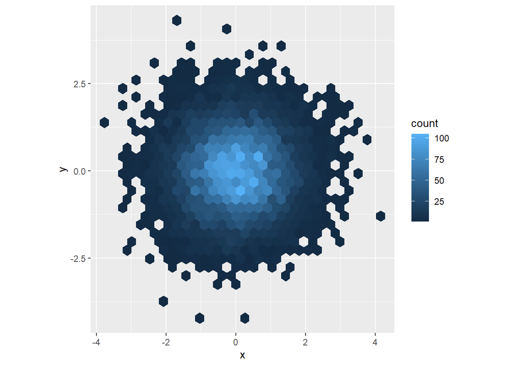

```r
df <- tibble(
  x = rnorm(10000),
  y = rnorm(10000)
)

ggplot(df, aes(x, y)) +
  geom_hex() +
  scale_color_gradient(low = "white", high = "red") +
  coord_fixed()
```

-Because the colors in geom_hex() are set by the fill aesthetic, not the color aesthetic.

2. What is the first argument to every scale? How does it compare to labs()?

-The first argument to every scale is the label for the scale. It is equivalent to using the labs function.

3. Change the display of the presidential terms by:

a.Combining the two variants that customize colors and x axis breaks. b.Improving the display of the y axis. c.Labelling each term with the name of the president. d.Adding informative plot labels. e.Placing breaks every 4 years (this is trickier than it seems!).

[figure not shown]

```r
fouryears <- lubridate::make_date(seq(year(min(presidential$start)),
  year(max(presidential$end)),
  by = 4
), 1, 1)

presidential %>%
  mutate(
    id = 33 + row_number(),
    name_id = fct_inorder(str_c(name, " (", id, ")"))
  ) %>%
  ggplot(aes(start, name_id, colour = party)) +
  geom_point() +
  geom_segment(aes(xend = end, yend = name_id)) +
  scale_colour_manual("Party", values = c(Republican = "red", Democratic = "blue")) +
  scale_y_discrete(NULL) +
  scale_x_date(NULL,
    breaks = presidential$start, date_labels = "'%y",
    minor_breaks = fouryears
  ) +
  ggtitle("Terms of US Presdients",
    subtitle = "Roosevelth (34th) to Obama (44th)"
  ) +
  theme(
    panel.grid.minor = element_blank(),
    axis.ticks.y = element_blank()
  )
```

4.First, create the following plot. Then, modify the code using override.aes to make the legend easier to see.

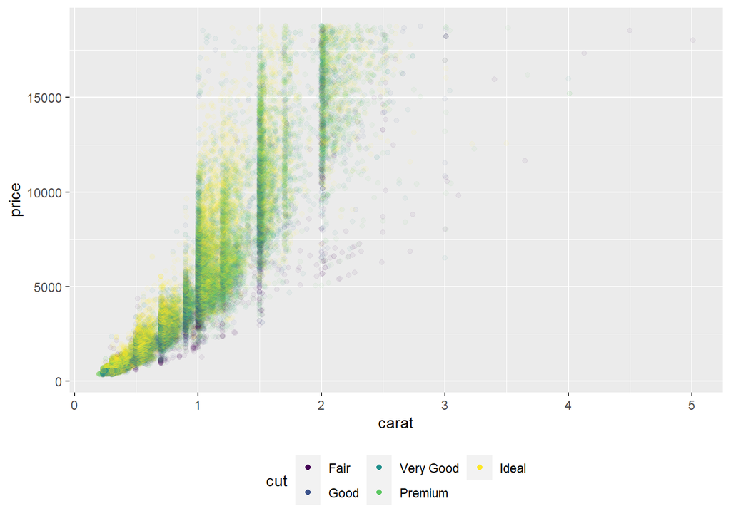

```r
ggplot(diamonds, aes(x = carat, y = price)) +
  geom_point(aes(color = cut), alpha = 1/20)+
  theme(legend.position = "bottom")+
  guides(color = guide_legend(nrow=2, override.aes = list(alpha = 1)))
```

## 12.5 Themes

### 12.5.1 Exercises

1. Pick a theme offered by the ggthemes package and apply it to the last plot you made.

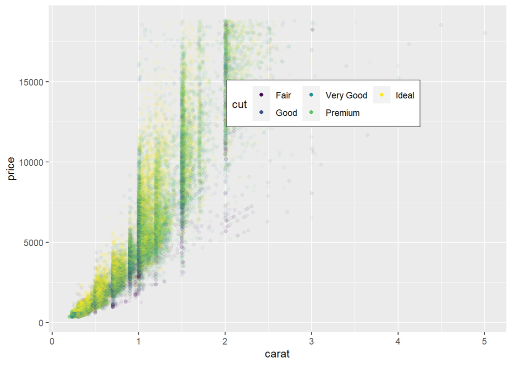

```r
ggplot(diamonds, aes(x = carat, y = price)) +
  geom_point(aes(color = cut), alpha = 1/20)+
  theme(legend.position = c(0.6, 0.7),
    legend.direction = "horizontal",
    legend.box.background = element_rect(color = "black"),
    plot.title = element_text(face = "bold"),
    plot.title.position = "plot",
    plot.caption.position = "plot",
    plot.caption = element_text(hjust = 0))+
  guides(color = guide_legend(nrow=2, override.aes = list(alpha = 1)))
```

## 12.6 Layout

### 12.6.1 Exercises

1. What happens if you omit the parentheses in the following plot layout. Can you explain why this happens?

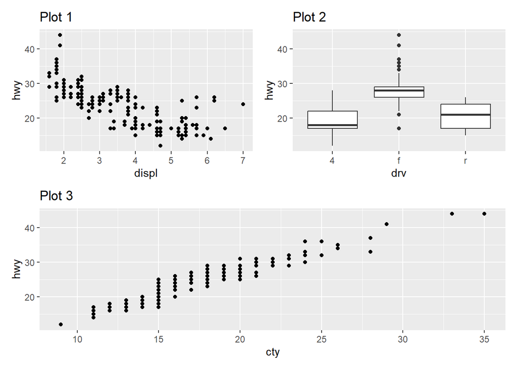

```r
p1 <- ggplot(mpg, aes(x = displ, y = hwy)) +
  geom_point() +
  labs(title = "Plot 1")
p2 <- ggplot(mpg, aes(x = drv, y = hwy)) +
  geom_boxplot() +
  labs(title = "Plot 2")
p3 <- ggplot(mpg, aes(x = cty, y = hwy)) +
  geom_point() +
  labs(title = "Plot 3")
(p1 | p2) / p3
```

-The plot layout would not be generated. Because，the parentheses designs the position of different plots in the layout.

2. Using the three plots from the previous exercise, recreate the following patchwork.

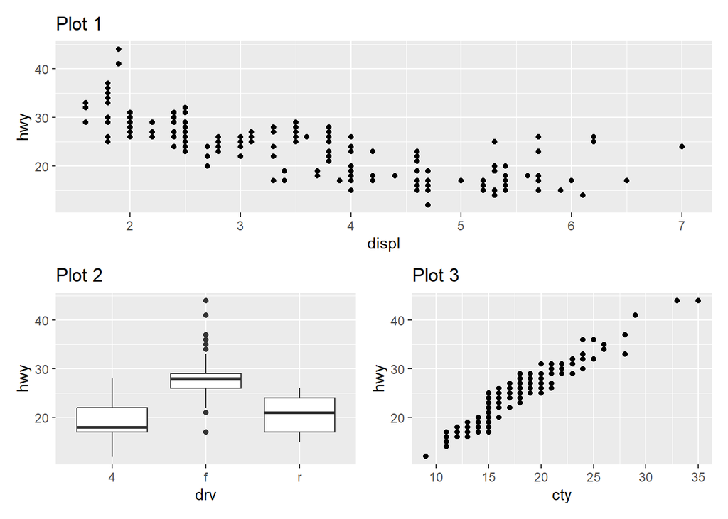

```r
po1 <- ggplot(mpg, aes(x = displ, y = hwy)) +
  geom_point() +
  labs(title = "Plot 1")

po2 <- ggplot(mpg, aes(x = drv, y = hwy)) +
  geom_boxplot() +
  labs(title = "Plot 2")

po3 <- ggplot(mpg, aes(x = cty, y = hwy)) +
  geom_point() +
  labs(title = "Plot 3")
po1/(po2 | po3)
```

# 13 Logical vectors

## 13.1 Introduction

### 13.1.1 Prerequisites

```r
library(tidyverse)
library(nycflights13)
#do to a variable inside a data frame with mutate()
```

## 13.2 Comparison

-We use filter() and <, <=, >, >=, != to make Comparison. -Use digits to compare floating point

1. How does dplyr::near() work? Type near to see the source code. Is sqrt(2)^2 near 2?

```r
near(sqrt(2)^2, 2)
```

```
## [1] TRUE
```

2. Use mutate(), is.na(), and count() together to describe how the missing values in dep_time, sched_dep_time and dep_delay are connected.

```r
flights |>
    mutate(dep_time_na = is.na(dep_time),
         sched_dep_time_na = is.na(sched_dep_time),
         dep_delay_na = is.na(dep_delay)) |>
  count(dep_time_na, sched_dep_time_na, dep_delay_na)
```

```
## # A tibble: 2 × 4
##   dep_time_na sched_dep_time_na dep_delay_na      n
##   <lgl>       <lgl>             <lgl>         <int>
## 1 FALSE       FALSE             FALSE        328521
## 2 TRUE        FALSE             TRUE           8255
```

## 13.3 Boolean algebra

1.Find all flights where arr_delay is missing but dep_delay is not. Find all flights where neither arr_time nor sched_arr_time are missing, but arr_delay is.

```r
#Find all flights where arr_delay is missing but dep_delay is not.
flights |>
  filter(is.na(arr_delay & ! dep_delay))
```

```
## # A tibble: 8,303 × 19
##     year month   day dep_time sched_dep_time dep_delay arr_time sched_arr_time
##    <int> <int> <int>    <int>          <int>     <dbl>    <int>          <int>
##  1  2013     1     1       NA           1630        NA       NA           1815
##  2  2013     1     1       NA           1935        NA       NA           2240
##  3  2013     1     1       NA           1500        NA       NA           1825
##  4  2013     1     1       NA            600        NA       NA            901
##  5  2013     1     2       NA           1540        NA       NA           1747
##  6  2013     1     2       NA           1620        NA       NA           1746
##  7  2013     1     2       NA           1355        NA       NA           1459
##  8  2013     1     2       NA           1420        NA       NA           1644
##  9  2013     1     2       NA           1321        NA       NA           1536
## 10  2013     1     2       NA           1545        NA       NA           1910
## # ℹ 8,293 more rows
## # ℹ 11 more variables: arr_delay <dbl>, carrier <chr>, flight <int>,
## #   tailnum <chr>, origin <chr>, dest <chr>, air_time <dbl>, distance <dbl>,
## #   hour <dbl>, minute <dbl>, time_hour <dttm>
```

```r
#Find all flights where neither arr_time nor sched_arr_time are missing
nycflights13::flights |>
  filter(is.na(sched_arr_time & arr_time & !arr_delay))
```

```
## # A tibble: 9,430 × 19
##     year month   day dep_time sched_dep_time dep_delay arr_time sched_arr_time
##    <int> <int> <int>    <int>          <int>     <dbl>    <int>          <int>
##  1  2013     1     1     1525           1530        -5     1934           1805
##  2  2013     1     1     1528           1459        29     2002           1647
##  3  2013     1     1     1740           1745        -5     2158           2020
##  4  2013     1     1     1807           1738        29     2251           2103
##  5  2013     1     1     1939           1840        59       29           2151
##  6  2013     1     1     1952           1930        22     2358           2207
##  7  2013     1     1     2016           1930        46       NA           2220
##  8  2013     1     1       NA           1630        NA       NA           1815
##  9  2013     1     1       NA           1935        NA       NA           2240
## 10  2013     1     1       NA           1500        NA       NA           1825
## # ℹ 9,420 more rows
## # ℹ 11 more variables: arr_delay <dbl>, carrier <chr>, flight <int>,
## #   tailnum <chr>, origin <chr>, dest <chr>, air_time <dbl>, distance <dbl>,
## #   hour <dbl>, minute <dbl>, time_hour <dttm>
```

2.How many flights have a missing dep_time? What other variables are missing in these rows? What might these rows represent?

```r
#How many flights have a missing dep_time
flights |>
  count(is.na(dep_time))
```

```
## # A tibble: 2 × 2
##   `is.na(dep_time)`      n
##   <lgl>              <int>
## 1 FALSE             328521
## 2 TRUE                8255
```

```r
#What other variables are missing in these rows?
summary(flights)
```

```
##       year          month             day           dep_time    sched_dep_time
##  Min.   :2013   Min.   : 1.000   Min.   : 1.00   Min.   :   1   Min.   : 106
##  1st Qu.:2013   1st Qu.: 4.000   1st Qu.: 8.00   1st Qu.: 907   1st Qu.: 906
##  Median :2013   Median : 7.000   Median :16.00   Median :1401   Median :1359
##  Mean   :2013   Mean   : 6.549   Mean   :15.71   Mean   :1349   Mean   :1344
##  3rd Qu.:2013   3rd Qu.:10.000   3rd Qu.:23.00   3rd Qu.:1744   3rd Qu.:1729
##  Max.   :2013   Max.   :12.000   Max.   :31.00   Max.   :2400   Max.   :2359
##                                                  NA's   :8255
##    dep_delay          arr_time    sched_arr_time   arr_delay
##  Min.   : -43.00   Min.   :   1   Min.   :   1   Min.   : -86.000
##  1st Qu.:  -5.00   1st Qu.:1104   1st Qu.:1124   1st Qu.: -17.000
##  Median :  -2.00   Median :1535   Median :1556   Median :  -5.000
##  Mean   :  12.64   Mean   :1502   Mean   :1536   Mean   :   6.895
##  3rd Qu.:  11.00   3rd Qu.:1940   3rd Qu.:1945   3rd Qu.:  14.000
##  Max.   :1301.00   Max.   :2400   Max.   :2359   Max.   :1272.000
##  NA's   :8255      NA's   :8713                  NA's   :9430
##    carrier              flight       tailnum             origin
##  Length:336776      Min.   :   1   Length:336776      Length:336776
##  Class :character   1st Qu.: 553   Class :character   Class :character
##  Mode  :character   Median :1496   Mode  :character   Mode  :character
##                     Mean   :1972
##                     3rd Qu.:3465
##                     Max.   :8500
##
##      dest              air_time        distance         hour
##  Length:336776      Min.   : 20.0   Min.   :  17   Min.   : 1.00
##  Class :character   1st Qu.: 82.0   1st Qu.: 502   1st Qu.: 9.00
##  Mode  :character   Median :129.0   Median : 872   Median :13.00
##                     Mean   :150.7   Mean   :1040   Mean   :13.18
##                     3rd Qu.:192.0   3rd Qu.:1389   3rd Qu.:17.00
##                     Max.   :695.0   Max.   :4983   Max.   :23.00
##                     NA's   :9430
##      minute        time_hour
##  Min.   : 0.00   Min.   :2013-01-01 05:00:00.00
##  1st Qu.: 8.00   1st Qu.:2013-04-04 13:00:00.00
##  Median :29.00   Median :2013-07-03 10:00:00.00
##  Mean   :26.23   Mean   :2013-07-03 05:22:54.64
##  3rd Qu.:44.00   3rd Qu.:2013-10-01 07:00:00.00
##  Max.   :59.00   Max.   :2013-12-31 23:00:00.00
##
```

-These rows might represent the cancelled flight

3.Assuming that a missing dep_time implies that a flight is cancelled, look at the number of cancelled flights per day. Is there a pattern? Is there a connection between the proportion of cancelled flights and the average delay of non-cancelled flights?

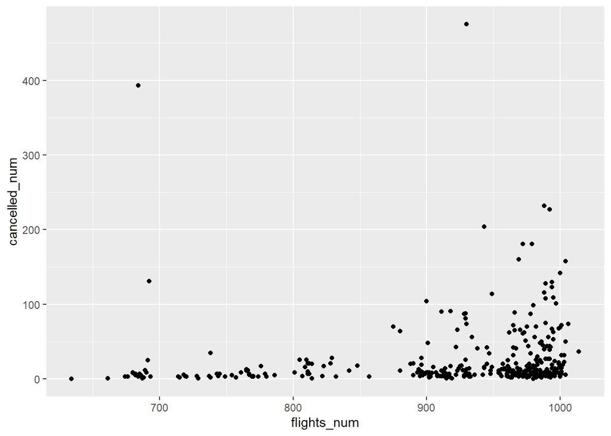

```r
#definitely cancelled.
cancelled_per_day <-
  flights %>%
  mutate(cancelled = (is.na(arr_delay) | is.na(dep_delay))) %>%
  group_by(year, month, day) %>%
  summarise(
    cancelled_num = sum(cancelled),
    flights_num = n(),
  )
# It is likely that days with more flights would have a higher probability of cancellations

ggplot(cancelled_per_day) +
  geom_point(aes(x = flights_num, y = cancelled_num))
```

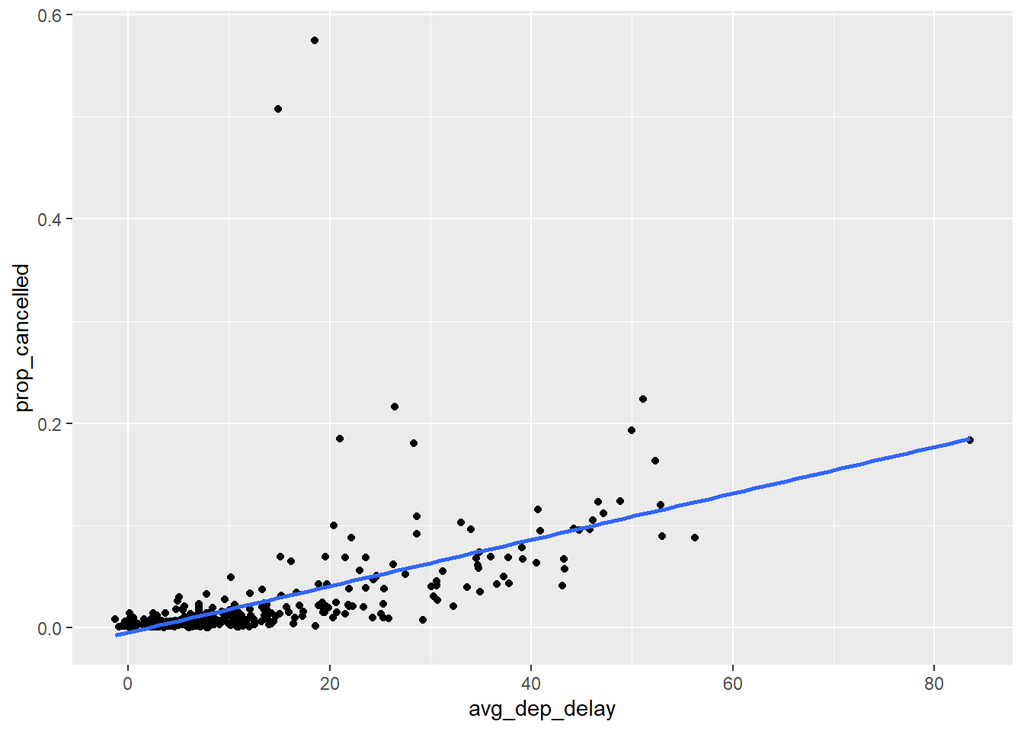

```r
#Is there a connection between the proportion of cancelled flights and the average delay of non-cancelled flights?

flights %>% group_by(month, day) %>%
  summarize(avg_dep_delay = mean(dep_delay, na.rm = TRUE),
            prop_cancelled = sum(is.na(dep_time)/n())) %>%
  ggplot(mapping = aes(x = avg_dep_delay, y = prop_cancelled)) +
  geom_point() +
  geom_smooth(method = 'lm', se = FALSE)
```

## 13.4 Summaries

### 13.4.1 Logical summaries

-There are two main logical summaries: any() and all(). any(x) is the equivalent of |; it’ll return TRUE if there are any TRUE’s in x. all(x) is equivalent of &; it’ll return TRUE only if all values of x are TRUE’s.

### 13.4.4 Exercises

1.What will sum(is.na(x)) tell you? How about mean(is.na(x))?

-sum(is.na(x)) will return the number of NAs in x by the number of TRUES. mean() gives the proportion of NAs in x by the form of TRUES

2.What does prod() return when applied to a logical vector? What logical summary function is it equivalent to? What does min() return when applied to a logical vector? What logical summary function is it equivalent to? Read the documentation and perform a few experiments.

-When applied to a lgocial vector, prod() will return the product of all the elements in the vector, treating TRUE as 1 and FALSE as 0. It equals to the & -When applied the min() function to a logical vector, it returns FALSE if there are any FALSE values in the vector, and TRUE if all values are TRUE. It’s equivalent to using the all() function.

## 13.5 Conditional transformations

### 13.5.1 if_else()

-In if_else(), the first argument, condition, is a logical vector, the second, true, gives the output when the condition is true, and the third, false, gives the output if the condition is false. There’s an optional fourth argument, missing which will be used if the input is NA.

### 13.5.2 case_when()

-It takes pairs that look like condition ~ output. condition must be a logical vector; when it’s TRUE, output will be used.

### 13.5.3 Compatible types

-Note that both if_else() and case_when() require compatible types in the output.

### Exerciese

1. A number is even if it’s divisible by two, which in R you can find out with x %% 2 == 0. Use this fact and if_else() to determine whether each number between 0 and 20 is even or odd.

```r
numbers <- 0:20
result <- if_else(numbers %% 2 == 0, "Even", "Odd")
result
```

```
##  [1] "Even" "Odd"  "Even" "Odd"  "Even" "Odd"  "Even" "Odd"  "Even" "Odd"
## [11] "Even" "Odd"  "Even" "Odd"  "Even" "Odd"  "Even" "Odd"  "Even" "Odd"
## [21] "Even"
```

2. Given a vector of days like x <- c(“Monday”, “Saturday”, “Wednesday”), use an ifelse() statement to label them as weekends or weekdays.

```r
x <- c("Monday", "Saturday", "Wednesday")
result <- ifelse(x %in% c("Saturday", "Sunday"), "Weekend", "Weekday")
result
```

```
## [1] "Weekday" "Weekend" "Weekday"
```

3. Use ifelse() to compute the absolute value of a numeric vector called x.

```r
x <- c(-5, 3, -7, 8, -2, 4, 6, -64, 15, -17)
abs_x <- ifelse(x < 0, -x, x)
abs_x
```

```
##  [1]  5  3  7  8  2  4  6 64 15 17
```

4. Write a case_when() statement that uses the month and day columns from flights to label a selection of important US holidays (e.g., New Years Day, 4th of July, Thanksgiving, and Christmas). First create a logical column that is either TRUE or FALSE, and then create a character column that either gives the name of the holiday or is NA.

```r
flights %>%
  mutate(
    is_holiday = case_when(
      (month == 1 & day == 1) ~ TRUE,          # New Year's Day
      (month == 7 & day == 4) ~ TRUE,          # 4th of July
      (month == 11 & day == 22) ~ TRUE,       # Thanksgiving
      (month == 12 & day == 25) ~ TRUE,       # Christmas
      TRUE ~ FALSE                            # Non-holiday
    ),
    holiday_name = case_when(
      is_holiday ~ "Holiday",
      TRUE ~ NA_character_))
```

```
## # A tibble: 336,776 × 21
##     year month   day dep_time sched_dep_time dep_delay arr_time sched_arr_time
##    <int> <int> <int>    <int>          <int>     <dbl>    <int>          <int>
##  1  2013     1     1      517            515         2      830            819
##  2  2013     1     1      533            529         4      850            830
##  3  2013     1     1      542            540         2      923            850
##  4  2013     1     1      544            545        -1     1004           1022
##  5  2013     1     1      554            600        -6      812            837
##  6  2013     1     1      554            558        -4      740            728
##  7  2013     1     1      555            600        -5      913            854
##  8  2013     1     1      557            600        -3      709            723
##  9  2013     1     1      557            600        -3      838            846
## 10  2013     1     1      558            600        -2      753            745
## # ℹ 336,766 more rows
## # ℹ 13 more variables: arr_delay <dbl>, carrier <chr>, flight <int>,
## #   tailnum <chr>, origin <chr>, dest <chr>, air_time <dbl>, distance <dbl>,
## #   hour <dbl>, minute <dbl>, time_hour <dttm>, is_holiday <lgl>,
## #   holiday_name <chr>
```

# 14 Numbers

## 14.1 Introduction

-We’ll start by giving you a couple of tools to make numbers if you have strings, and then going into a little more detail of count(). Then we’ll dive into various numeric transformations that pair well with mutate(), including more general transformations that can be applied to other types of vectors, but are often used with numeric vectors. We’ll finish off by covering the summary functions that pair well with summarize() and show you how they can also be used with mutate().

### 14.1.1 Prerequisites

```r
library(tidyverse)
library(nycflights13)
```

## 14.2 Making numbers

```r
x <- c("1.2", "5.6", "1e3")
parse_double(x)
```

```
## [1]    1.2    5.6 1000.0
```

```r
# Use parse_number() when the string contains non-numeric text that you want to ignore.
x <- c("$1,234", "USD 3,513", "59%")
parse_number(x)
```

```
## [1] 1234 3513   59
```

## 14.3 Counts

```r
#How count() works
flights |> count(dest)
```

```
## # A tibble: 105 × 2
##    dest      n
##    <chr> <int>
##  1 ABQ     254
##  2 ACK     265
##  3 ALB     439
##  4 ANC       8
##  5 ATL   17215
##  6 AUS    2439
##  7 AVL     275
##  8 BDL     443
##  9 BGR     375
## 10 BHM     297
## # ℹ 95 more rows
```

```r
#If you want to see the most common values, add sort = TRUE
flights |> count(dest, sort = TRUE)
```

```
## # A tibble: 105 × 2
##    dest      n
##    <chr> <int>
##  1 ORD   17283
##  2 ATL   17215
##  3 LAX   16174
##  4 BOS   15508
##  5 MCO   14082
##  6 CLT   14064
##  7 SFO   13331
##  8 FLL   12055
##  9 MIA   11728
## 10 DCA    9705
## # ℹ 95 more rows
```

```r
#if you want to see all the values, you can use |> View() or |> print(n = Inf).
#You can perform the same computation “by hand” with group_by(), summarize() and n().

flights |>
  group_by(dest) |>
  summarize(
    n = n(),
    delay = mean(arr_delay, na.rm = TRUE))
```

```
## # A tibble: 105 × 3
##    dest      n delay
##    <chr> <int> <dbl>
##  1 ABQ     254  4.38
##  2 ACK     265  4.85
##  3 ALB     439 14.4
##  4 ANC       8 -2.5
##  5 ATL   17215 11.3
##  6 AUS    2439  6.02
##  7 AVL     275  8.00
##  8 BDL     443  7.05
##  9 BGR     375  8.03
## 10 BHM     297 16.9
## # ℹ 95 more rows
```

```r
#n_distinct(x) counts the number of distinct (unique) values of one or more variables.
flights |>
  group_by(dest) |>
  summarize(carriers = n_distinct(carrier)) |>
  arrange(desc(carriers))
```

```
## # A tibble: 105 × 2
##    dest  carriers
##    <chr>    <int>
##  1 ATL          7
##  2 BOS          7
##  3 CLT          7
##  4 ORD          7
##  5 TPA          7
##  6 AUS          6
##  7 DCA          6
##  8 DTW          6
##  9 IAD          6
## 10 MSP          6
## # ℹ 95 more rows
```

```r
#A weighted count is a sum. For example you could “count” the number of miles each plane flew:
flights |>
  group_by(tailnum) |>
  summarize(miles = sum(distance))
```

```
## # A tibble: 4,044 × 2
##    tailnum  miles
##    <chr>    <dbl>
##  1 D942DN    3418
##  2 N0EGMQ  250866
##  3 N10156  115966
##  4 N102UW   25722
##  5 N103US   24619
##  6 N104UW   25157
##  7 N10575  150194
##  8 N105UW   23618
##  9 N107US   21677
## 10 N108UW   32070
## # ℹ 4,034 more rows
```

```r
#Weighted counts are a common problem so count() has a wt argument that does the same thing:
flights |> count(tailnum, wt = distance)
```

```
## # A tibble: 4,044 × 2
##    tailnum      n
##    <chr>    <dbl>
##  1 D942DN    3418
##  2 N0EGMQ  250866
##  3 N10156  115966
##  4 N102UW   25722
##  5 N103US   24619
##  6 N104UW   25157
##  7 N10575  150194
##  8 N105UW   23618
##  9 N107US   21677
## 10 N108UW   32070
## # ℹ 4,034 more rows
```

```r
#You can count missing values by combining sum() and is.na().
flights |>
  group_by(dest) |>
  summarize(n_cancelled = sum(is.na(dep_time)))
```

```
## # A tibble: 105 × 2
##    dest  n_cancelled
##    <chr>       <int>
##  1 ABQ             0
##  2 ACK             0
##  3 ALB            20
##  4 ANC             0
##  5 ATL           317
##  6 AUS            21
##  7 AVL            12
##  8 BDL            31
##  9 BGR            15
## 10 BHM            25
## # ℹ 95 more rows
```

### 14.3.1 Exercises

1.How can you use count() to count the number rows with a missing value for a given variable?

```r
flights |>
  group_by(dest) |>
  count(is.na(dep_time))
```

```
## # A tibble: 203 × 3
## # Groups:   dest [105]
##    dest  `is.na(dep_time)`     n
##    <chr> <lgl>             <int>
##  1 ABQ   FALSE               254
##  2 ACK   FALSE               265
##  3 ALB   FALSE               419
##  4 ALB   TRUE                 20
##  5 ANC   FALSE                 8
##  6 ATL   FALSE             16898
##  7 ATL   TRUE                317
##  8 AUS   FALSE              2418
##  9 AUS   TRUE                 21
## 10 AVL   FALSE               263
## # ℹ 193 more rows
```

2.Expand the following calls to count() to instead use group_by(), summarize(), and arrange(): flights |> count(dest, sort = TRUE)

flights |> count(tailnum, wt = distance)

```r
flights |>
  group_by(dest) |>
  summarize(n = n()) |>
  arrange(desc(n))
```

```
## # A tibble: 105 × 2
##    dest      n
##    <chr> <int>
##  1 ORD   17283
##  2 ATL   17215
##  3 LAX   16174
##  4 BOS   15508
##  5 MCO   14082
##  6 CLT   14064
##  7 SFO   13331
##  8 FLL   12055
##  9 MIA   11728
## 10 DCA    9705
## # ℹ 95 more rows
```

```r
flights |>
  group_by(tailnum) |>
  summarize(total_distance = sum(distance, na.rm = TRUE)) |>
  arrange(desc(total_distance))
```

```
## # A tibble: 4,044 × 2
##    tailnum total_distance
##    <chr>            <dbl>
##  1 <NA>           1784167
##  2 N328AA          939101
##  3 N338AA          931183
##  4 N327AA          915665
##  5 N335AA          909696
##  6 N323AA          844529
##  7 N319AA          840510
##  8 N336AA          838086
##  9 N329AA          830776
## 10 N324AA          794895
## # ℹ 4,034 more rows
```

## 14.4 Numeric transformations

### 14.4.1 Arithmetic and recycling rules

1. Explain in words what each line of the code used to generate Figure 14.1 does.

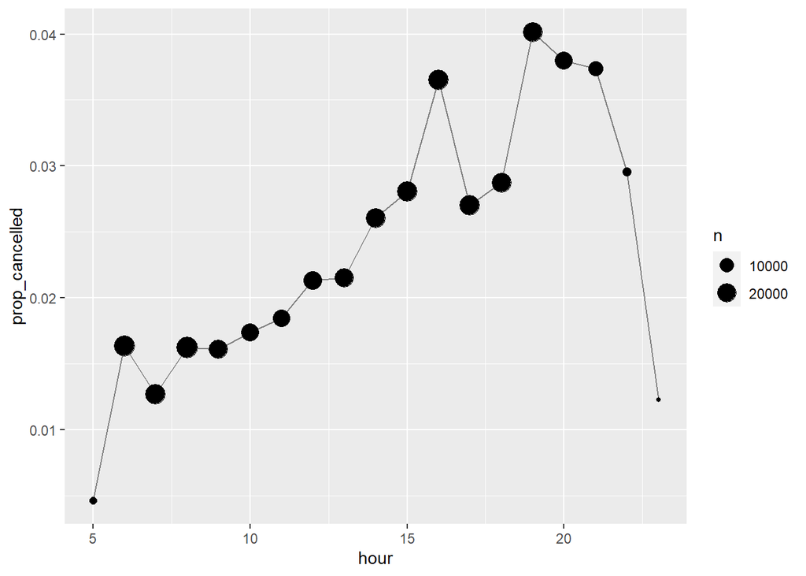

```r
flights |>  #Designate flight data set for extracting
  group_by(hour = sched_dep_time %/% 100) |>  #This line groups the data by the "hour" variable, which is created by dividing the "sched_dep_time" column by 100 (to extract the hour portion of the departure time).
  summarize(prop_cancelled = mean(is.na(dep_time)), n = n()) |>  # It calculates the proportion of canceled flights (prop_cancelled) using the mean of is.na(dep_time) and also calculates the total count of flights (n) in each group.
  filter(hour > 1) |> # Filter out groups where the "hour" is greater than 1
  ggplot(aes(x = hour, y = prop_cancelled)) + #Plot with "hour" on the x-axis and "prop_cancelled" on the y-axis
  geom_line(color = "grey50") + # This line adds a line layer to the plot, creating a line plot. The "color" parameter sets the color of the line to grey50.
  geom_point(aes(size = n))#  Add point markers to the plot, where the size of the points is mapped to the "n" variable.
```

2. What trigonometric functions does R provide? Guess some names and look up the documentation. Do they use degrees or radians?

-sin(x): Returns the sine of the angle x, where x is in radians. -cos(x): Returns the cosine of the angle x, where x is in radians. -tan(x): Returns the tangent of the angle x, where x is in radians. -These functions typically use radians for angle measurement.

3. Currently dep_time and sched_dep_time are convenient to look at, but hard to compute with because they’re not really continuous numbers. You can see the basic problem by running the code below: there’s a gap between each hour.

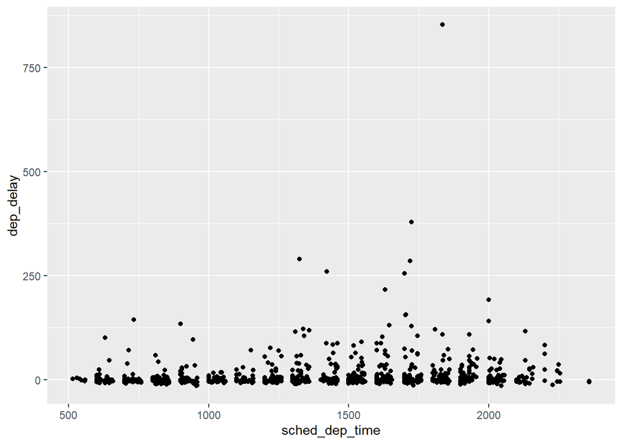

```r
#Original
flights |>
  filter(month == 1, day == 1) |>
  ggplot(aes(x = sched_dep_time, y = dep_delay)) +
  geom_point()
```

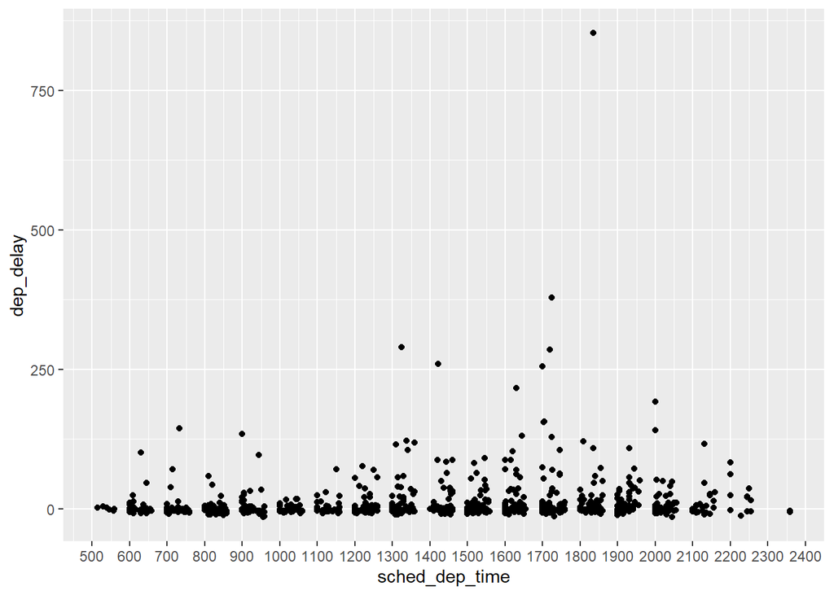

```r
#Modification
flights |>
  filter(month == 1, day == 1) |>
  ggplot(aes(x = sched_dep_time, y = dep_delay)) +
  geom_point() +
  scale_x_continuous(breaks = seq(0, 2400, by = 100))
```

4. Convert them to a more truthful representation of time (either fractional hours or minutes since midnight).

Round dep_time and arr_time to the nearest five minutes.

```r
# Convert dep_time and arr_time to fractional hours
flights <- flights |>
  mutate(
    dep_time = floor(dep_time / 100) + (dep_time %% 100) / 60,
    arr_time = floor(arr_time / 100) + (arr_time %% 100) / 60
  )

# Round dep_time and arr_time to the nearest five minutes

flights <- flights |>
  mutate(
    dep_time = round(dep_time * 12) / 12,  # 5 minutes per unit
    arr_time = round(arr_time * 12) / 12
  )
```

## 14.5 General transformations

### 14.5.1 Ranks

```r
#Note that the smallest values get the lowest ranks; use desc(x) to give the largest values the smallest ranks:
x <- c(1, 2, 2, 3, 4, NA)
min_rank(desc(x))
```

```
## [1]  5  3  3  2  1 NA
```

-View documents of dplyr::row_number(), dplyr::dense_rank(), dplyr::percent_rank(), and dplyr::cume_dist()

### 14.5.2 Offsets

```r
#dplyr::lead() and dplyr::lag() allow you to refer the values just before or just after the “current” value. They return a vector of the same length as the input, padded with NAs at the start or end:

x <- c(2, 5, 11, 11, 19, 35)
lag(x)
```

```
## [1] NA  2  5 11 11 19
```

```r
lead(x)
```

```
## [1]  5 11 11 19 35 NA
```

```r
#x - lag(x) gives you the difference between the current and previous value.
x - lag(x)
```

```
## [1] NA  3  6  0  8 16
```

```r
#x == lag(x) tells you when the current value changes.
x == lag(x)
```

```
## [1]    NA FALSE FALSE  TRUE FALSE FALSE
```

### 14.5.3 Consecutive identifiers

- cumsum() will increment group by one.
- Another approach for creating grouping variables is consecutive_id(), which starts a new group every time one of its arguments changes.
- To keep the first row from each repeated x, you could use group_by(), consecutive_id(), and slice_head()

### Exercise

1.Find the 10 most delayed flights using a ranking function. How do you want to handle ties? Carefully read the documentation for min_rank().

```r
flights |>
  arrange(desc(dep_delay)) |>
  mutate(rank = min_rank(desc(dep_delay))) |>
  filter(rank <= 10)
```

```
## # A tibble: 10 × 20
##     year month   day dep_time sched_dep_time dep_delay arr_time sched_arr_time
##    <int> <int> <int>    <dbl>          <int>     <dbl>    <dbl>          <int>
##  1  2013     1     9     6.67            900      1301    12.7            1530
##  2  2013     6    15    14.5            1935      1137    16.1            2120
##  3  2013     1    10    11.3            1635      1126    12.7            1810
##  4  2013     9    20    11.7            1845      1014    14.9            2210
##  5  2013     7    22     8.75           1600      1005    10.8            1815
##  6  2013     4    10    11              1900       960    13.7            2211
##  7  2013     3    17    23.3             810       911     1.58           1020
##  8  2013     6    27    10              1900       899    12.6            2226
##  9  2013     7    22    22.9             759       898     1.33           1026
## 10  2013    12     5     7.92           1700       896    11              2020
## # ℹ 12 more variables: arr_delay <dbl>, carrier <chr>, flight <int>,
## #   tailnum <chr>, origin <chr>, dest <chr>, air_time <dbl>, distance <dbl>,
## #   hour <dbl>, minute <dbl>, time_hour <dttm>, rank <int>
```

2.Which plane (tailnum) has the worst on-time record?

```r
flights |>
  group_by(tailnum) |>
  summarize(average_delay = mean(dep_delay, na.rm = TRUE)) |>
  arrange(average_delay, na.last = TRUE)
```

```
## # A tibble: 4,044 × 2
##    tailnum average_delay
##    <chr>           <dbl>
##  1 N785SK          -14
##  2 N710SK          -13
##  3 N701SK          -11
##  4 N726SK          -11
##  5 N859AS          -11
##  6 N17627          -10.5
##  7 N14628          -10
##  8 N794SK          -10
##  9 N583AS           -9.5
## 10 N509AA           -9
## # ℹ 4,034 more rows
```

3.What time of day should you fly if you want to avoid delays as much as possible?

```r
flights <- flights |>
  mutate(hour = as.numeric(substring(sched_dep_time, 1, 2)))

average_delay_by_hour <- flights |>
  group_by(hour) |>
  summarize(average_delay = mean(dep_delay, na.rm = TRUE))

average_delay_by_hour |>
  filter(average_delay == min(average_delay))
```

```
## # A tibble: 1 × 2
##    hour average_delay
##   <dbl>         <dbl>
## 1    50         -3.11
```

4.What does flights |> group_by(dest) |> filter(row_number() < 4) do? What does flights |> group_by(dest) |> filter(row_number(dep_delay) < 4) do?

-The first line of codes filters the grouped data to keep only the rows where the row number (order within each destination group) is less than 4 by ‘dest’ -The second line filters the data based on the row numbers within each destination group considering the ‘dep_delay’ column. It selects the first three rows within each destination group

5.For each destination, compute the total minutes of delay. For each flight, compute the proportion of the total delay for its destination.

```r
#Calculate the total minutes of delay for each destination
destination_dt <- flights |>
  group_by(dest) |>
  summarize(total_delay = sum(dep_delay, na.rm = TRUE))

#Join the origianl dataset
new_flights <- flights |>
  left_join(destination_dt, by = "dest")

#Calculate the proportion of the total delay for each flight's destination
new_flights |>
  mutate(proportion_of_total_delay = dep_delay / total_delay)
```

```
## # A tibble: 336,776 × 21
##     year month   day dep_time sched_dep_time dep_delay arr_time sched_arr_time
##    <int> <int> <int>    <dbl>          <int>     <dbl>    <dbl>          <int>
##  1  2013     1     1     5.25            515         2     8.5             819
##  2  2013     1     1     5.58            529         4     8.83            830
##  3  2013     1     1     5.67            540         2     9.42            850
##  4  2013     1     1     5.75            545        -1    10.1            1022
##  5  2013     1     1     5.92            600        -6     8.17            837
##  6  2013     1     1     5.92            558        -4     7.67            728
##  7  2013     1     1     5.92            600        -5     9.25            854
##  8  2013     1     1     5.92            600        -3     7.17            723
##  9  2013     1     1     5.92            600        -3     8.67            846
## 10  2013     1     1     6               600        -2     7.92            745
## # ℹ 336,766 more rows
## # ℹ 13 more variables: arr_delay <dbl>, carrier <chr>, flight <int>,
## #   tailnum <chr>, origin <chr>, dest <chr>, air_time <dbl>, distance <dbl>,
## #   hour <dbl>, minute <dbl>, time_hour <dttm>, total_delay <dbl>,
## #   proportion_of_total_delay <dbl>
```

6.Delays are typically temporally correlated: even once the problem that caused the initial delay has been resolved, later flights are delayed to allow earlier flights to leave. Using lag(), explore how the average flight delay for an hour is related to the average delay for the previous hour.

```r
#The original set
flights |>
  mutate(hour = dep_time %/% 100) |>
  group_by(year, month, day, hour) |>
  summarize(
    dep_delay = mean(dep_delay, na.rm = TRUE),
    n = n(),
    .groups = "drop"
  ) |>
  filter(n > 5)
```

```
## # A tibble: 578 × 6
##     year month   day  hour dep_delay     n
##    <int> <int> <int> <dbl>     <dbl> <int>
##  1  2013     1     1     0     11.5    838
##  2  2013     1     2     0     13.9    935
##  3  2013     1     2    NA    NaN        8
##  4  2013     1     3     0     11.0    904
##  5  2013     1     3    NA    NaN       10
##  6  2013     1     4     0      8.95   909
##  7  2013     1     4    NA    NaN        6
##  8  2013     1     5     0      5.73   717
##  9  2013     1     6     0      7.15   831
## 10  2013     1     7     0      5.42   930
## # ℹ 568 more rows
```

```r
#Modified
flights |>
  mutate(hour = dep_time %/% 100) |>
  group_by(year, month, day, hour) |>
  summarize(
    dep_delay = mean(dep_delay, na.rm = TRUE),
    n = n(),
    .groups = "drop"
  ) |>
  filter(n > 5) |>
  mutate(prev_hour_delay = lag(dep_delay)) |>
  na.omit()
```

```
## # A tibble: 152 × 7
##     year month   day  hour dep_delay     n prev_hour_delay
##    <int> <int> <int> <dbl>     <dbl> <int>           <dbl>
##  1  2013     1     2     0    13.9     935           11.5
##  2  2013     1     6     0     7.15    831            5.73
##  3  2013     1     7     0     5.42    930            7.15
##  4  2013     1     8     0     2.55    895            5.42
##  5  2013     1     9     0     2.28    897            2.55
##  6  2013     1    10     0     2.84    929            2.28
##  7  2013     1    11     0     2.82    919            2.84
##  8  2013     1    15     0     0.124   881            2.79
##  9  2013     1    20     0     6.78    782            3.48
## 10  2013     1    21     0     7.83    904            6.78
## # ℹ 142 more rows
```

7.Look at each destination. Can you find flights that are suspiciously fast (i.e. flights that represent a potential data entry error)? Compute the air time of a flight relative to the shortest flight to that destination. Which flights were most delayed in the air?

```r
#Find the shortest flight to each destination
shortest_flight <- flights |>
  group_by(dest) |>
  filter(air_time == min(air_time)) |>
  select(dest, shortest_time = air_time)
shortest_flight
```

```
## # A tibble: 5 × 2
## # Groups:   dest [5]
##   dest  shortest_time
##   <chr>         <dbl>
## 1 LEX              90
## 2 EYW             155
## 3 ABQ             212
## 4 ANC             388
## 5 SBN              88
```

```r
#Compute the air time of a flight relative to the shortest flight to that destination.
flights |>
  left_join(shortest_flight, by = "dest") |>
  mutate(relative_air_time = air_time / shortest_time) |>
  arrange(desc(relative_air_time)) |>
  head(10)
```

```
## # A tibble: 10 × 21
##     year month   day dep_time sched_dep_time dep_delay arr_time sched_arr_time
##    <int> <int> <int>    <dbl>          <int>     <dbl>    <dbl>          <int>
##  1  2013    12    10     20.8           2001        43    0.833           2304
##  2  2013    12     8     20.8           2001        48    1               2304
##  3  2013    12     7     20             2001        -2   23.9             2304
##  4  2013    10    30     19.9           2000        -6   23.5             2303
##  5  2013    12     6     20.2           2001         7   23.8             2304
##  6  2013    10    18     20             2001         0   23.5             2248
##  7  2013    12     9     20.4           2001        22    0               2304
##  8  2013    11    23     19.9           2000        -3   23.6             2303
##  9  2013    12     5     20.2           2001         9   23.6             2304
## 10  2013    12     3     20.3           2001        19   23.4             2304
## # ℹ 13 more variables: arr_delay <dbl>, carrier <chr>, flight <int>,
## #   tailnum <chr>, origin <chr>, dest <chr>, air_time <dbl>, distance <dbl>,
## #   hour <dbl>, minute <dbl>, time_hour <dttm>, shortest_time <dbl>,
## #   relative_air_time <dbl>
```

-Flight N729JB, N531JB, and N566JB are the top three most delayed in the air ?

8.Find all destinations that are flown by at least two carriers. Use those destinations to come up with a relative ranking of the carriers based on their performance for the same destination.

```r
#Find all destinations that are flown by at least two carriers.
destinations_with_twomore_carriers <- flights |>
  group_by(dest) |>
  mutate(carrier_count = n_distinct(carrier)) |>
  filter(carrier_count >= 2) |>
  distinct(dest)

#Lets see the relative ranking of the carriers based on their performance for the same destination.
flights |>
  filter(dest %in% destinations_with_twomore_carriers$dest) |>
  group_by(carrier, dest) |>
  summarize(avg_dep_delay = mean(dep_delay, na.rm = TRUE)) |>
  group_by(carrier) |>
  summarize(relative_rank = mean(avg_dep_delay, na.rm = TRUE)) |>
  arrange(relative_rank)
```

```
## # A tibble: 16 × 2
##    carrier relative_rank
##    <chr>           <dbl>
##  1 US               3.85
##  2 HA               4.90
##  3 AS               5.80
##  4 VX               7.01
##  5 DL               7.17
##  6 FL               8.37
##  7 AA               9.90
##  8 MQ              11.2
##  9 YV              12.0
## 10 UA              12.5
## 11 9E              12.5
## 12 B6              13.0
## 13 WN              15.6
## 14 EV              19.4
## 15 F9              20.2
## 16 OO              27.6
```